# Introduction to Statistics and Machine Learning

Oliver M. Crook

27 June 2019

Many of these example have been taken and adapted from

Modern Statistics for Modern Biology; Susan Holmes and Wolfgang Huber

An Introduction to Statistical Learning; James, Witten, Hastie, Tibshirnani

The Elements to Statistical Learning; Friedman, Tibshirani, Hastie

# Section: Testing

## Is my coin biased?

```r
set.seed(2) # sets a random seed
numFlips = 100
probHead = 0.59
coinFlips = sample(c("H", "T"), size = numFlips,
  replace = TRUE, prob = c(probHead, 1 - probHead))
head(coinFlips)
```

```
## [1] "H" "T" "H" "H" "T" "T"
```

If the coin were unbiased we expect roughly 50 heads. Let us see how many heads and tails there are.

```r
table(coinFlips)
```

```
## coinFlips
##  H  T
## 62 38
```

We calculate the binomial statistic for a number of flips between 0 and 100. This is the binomial density for an unbiased coin.

```r
library("dplyr")
k = 0:numFlips
numHeads = sum(coinFlips == "H")
binomDensity = tibble(k = k,
     p = dbinom(k, size = numFlips, prob = 0.5))
```

Questions: 1) Write some code to check that the probabilties from the binomial statistic sum to $1$.

2. change the prob argument show that the probabilities still some to $1$.

The following code chunk plots the binomial statistic and the number of heads observed is marked in blue.

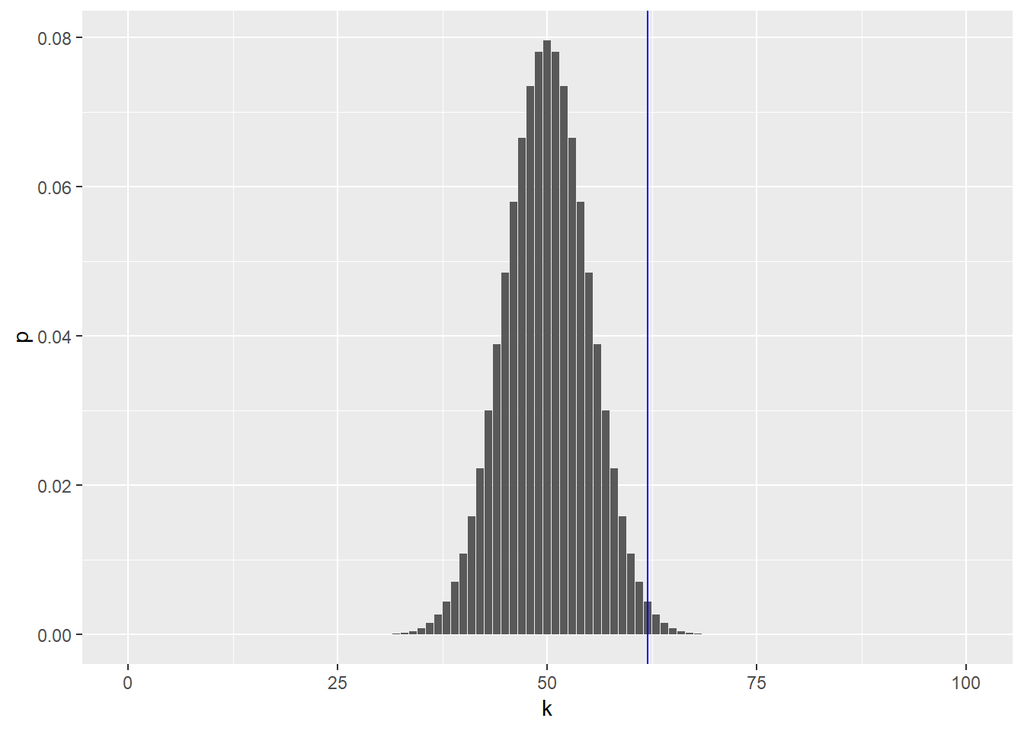

```r
library("ggplot2")
ggplot(binomDensity) +
  geom_bar(aes(x = k, y = p), stat = "identity") +
  geom_vline(xintercept = numHeads, col = "blue")
```

Question:

3. Change the prob argument above and replot the binomial statistic, what do you notice about how the distribution is centered?

Now, we set the size of the reject threshold

```r
alpha = 0.05
```

Question:

4. Without looking below use the arrange function from dplyr to order the probabilities, smallest first.
5. Looking at the output, what is the most unlikely number of heads to observe?
6. Looking at the output, what is the most likely number of heads to observe?

Solution:

```r
orderBinomDenisty <- arrange(binomDensity, p)
orderBinomDenisty[1,] # most unlikely
```

```
## # A tibble: 1 x 2
##       k        p
##   <int>    <dbl>
## 1     0 7.89e-31
```

```r
orderBinomDenisty[101,]
```

```
## # A tibble: 1 x 2
##       k      p
##   <int>  <dbl>
## 1    50 0.0796
```

Question:

7. What does the following code chunk do?

```r
binomDensity =  arrange(binomDensity, p) %>%
        mutate(reject = (cumsum(p) <= alpha))
```

Let us plot the reject region in red

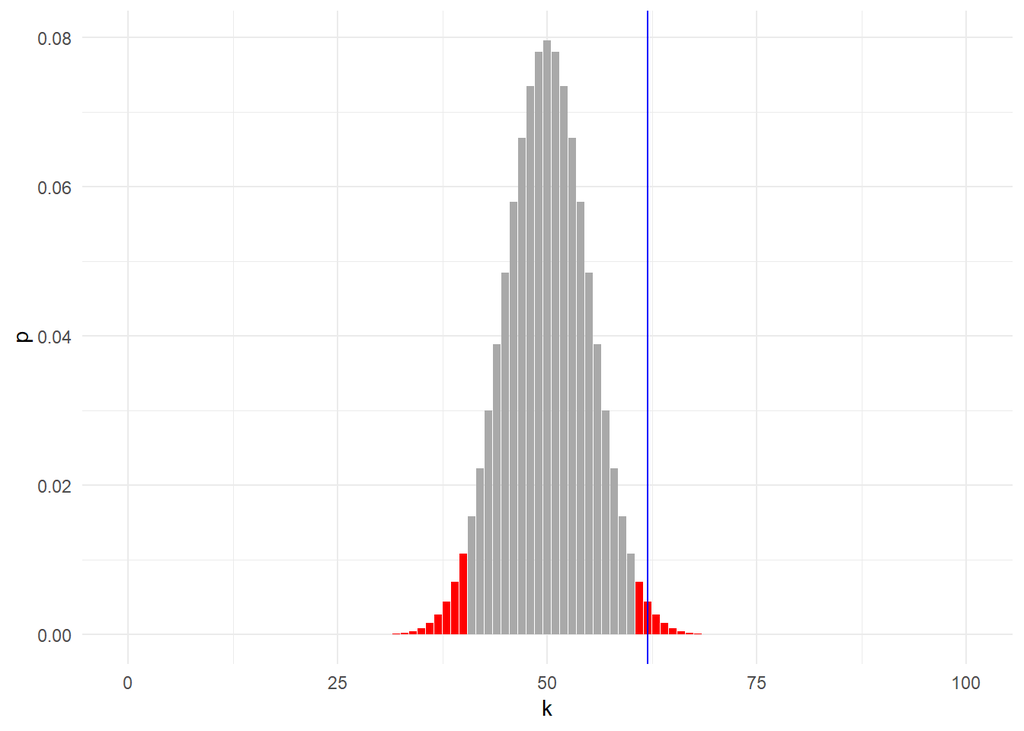

```r
ggplot(binomDensity) +
  geom_bar(aes(x = k, y = p, fill = reject), stat = "identity") +
  scale_fill_manual(
    values = c(`TRUE` = "red", `FALSE` = "darkgrey")) + theme_minimal() +
  geom_vline(xintercept = numHeads, col = "blue") +
  theme(legend.position = "none")
```

Questions:

8. Is there evidence that are coin is biased?
9. Change the size of the reject region to a smaller value, what is our conclusion now?

The above test already has an easy to use funciton in R:

```r
binom.test(x = numHeads, n = numFlips, p = 0.5)
```

```
##
##  Exact binomial test
##
## data:  numHeads and numFlips
## number of successes = 62, number of trials = 100, p-value =
## 0.02098
## alternative hypothesis: true probability of success is not equal to 0.5
## 95 percent confidence interval:
##  0.5174607 0.7152325
## sample estimates:
## probability of success
##                   0.62
```

## The t-test

The following is some plant growth data with 2 treatments. The alpha parameter below has nothing to do with the reject region before. It changes the see-throughness of the points to better visualise overlapping points. Have a go at changing it.

```r
library("ggbeeswarm")
```

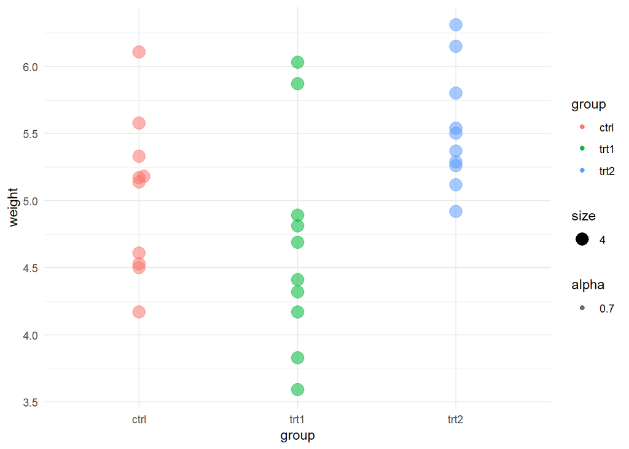

```r
data("PlantGrowth")
ggplot(PlantGrowth, aes(y = weight, x = group, col = group, size = 4, alpha = 0.7)) +
  geom_beeswarm() + theme(legend.position = "none") + theme_minimal()
```

Let us take a look at the PlantGrowth data

```r
head(PlantGrowth)
```

```
##   weight group
## 1   4.17  ctrl
## 2   5.58  ctrl
## 3   5.18  ctrl
## 4   6.11  ctrl
## 5   4.50  ctrl
## 6   4.61  ctrl
```

Question:

10. Using a t-test, check to see whether the difference in means of the ctrl and treatment 1 are different

Solution

```r
t.test(PlantGrowth$weight[PlantGrowth$group == "ctrl"], PlantGrowth$weight[PlantGrowth$group == "trt1"], var.equal = TRUE)
```

```
##
##  Two Sample t-test
##
## data:  PlantGrowth$weight[PlantGrowth$group == "ctrl"] and PlantGrowth$weight[PlantGrowth$group == "trt1"]
## t = 1.1913, df = 18, p-value = 0.249
## alternative hypothesis: true difference in means is not equal to 0
## 95 percent confidence interval:
##  -0.2833003  1.0253003
## sample estimates:
## mean of x mean of y
##     5.032     4.661
```

Questions:

11. What is the p-value?
12. Check the degrees of freedom is correct from the formula?
13. How do the assumptions of the t-test match up with the data?
14. Check the arguments of the t.test function? What happens if you change the equal variance assumption?

You may find the following code useful.

```r
tt = with(PlantGrowth,
          t.test(weight[group =="ctrl"],
                 weight[group =="trt2"],
                 var.equal = TRUE))
tt
```

```
##
##  Two Sample t-test
##
## data:  weight[group == "ctrl"] and weight[group == "trt2"]
## t = -2.134, df = 18, p-value = 0.04685
## alternative hypothesis: true difference in means is not equal to 0
## 95 percent confidence interval:
##  -0.980338117 -0.007661883
## sample estimates:
## mean of x mean of y
##     5.032     5.526
```